# NBA STATISTICS

with a focus on efficiency

Moriah Taylor

11/26/2019

## THE DATA

The data I’m working with is scraped from the website *basketball-reference.com*. I pulled a variety of information from this site, the first of which was player statistics averaged per season from the years 1997 to 2016. I purposefully centered the data around the 2006-07 season because this was the first season that the one-and-done rule took effect which is crucial to the last part of my report. I also pulled what biographical information was available (not all players had biography pages) as well as the MVP voting results for each of these seasons.

## NBA EFFICIENCY

The formula for NBA Efficiency was invented by Martin Manley and its formulation is as follows:  
> NBA Efficiency = (Points)+(Rebounds)+(Steals)+(Assists)+(Blocked Shots)-(Turnovers)-(Missed Shots)

This is a standard and simple metric used to evaluate player performance. One con often cited with this measure is that it is not as precise as possession-based statistics because it is not adjusted for game pace, but because I am working with the average statistics across an entire season, this is not an issue.

## “IS LEBRON JAMES THE BEST PLAYER IN THE LEAGUE?”

This is a question that is passionately debated among NBA fanatics. For fun, I decided to see if the data I gathered supported this claim. In order to compare LeBron James to similar-caliber players, I chose to subset the data to the players that were considered for the MVP award for the seasons that LeBron was in the league (2004-2016). Because LeBron has been considered for the MVP award every season in this time frame, I thought this would be a fair way to determine comparable players.

I conducted a hypothesis test to evaluate whether LeBron’s efficiency is significantly better than the efficiency of other high-performing players. The resulting p-value was less than 0.0001 (t=10.9771, df=11) indicating that LeBron’s efficiency was very significantly higher than his peers. This test provides convincing (although not definitive) evidence of LeBron’s superiority to other players.

```
## Response variable: numerical
## Explanatory variable: categorical (2 levels)
## n_LeBron = 12, y_bar_LeBron = 31.3, s_LeBron = 2.2474
## n_Not LeBron = 163, y_bar_Not LeBron = 23.0442, s_Not LeBron = 4.8572
## H0: mu_LeBron =  mu_Not LeBron
## HA: mu_LeBron > mu_Not LeBron
## t = 10.9771, df = 11
## p_value = < 0.0001
```

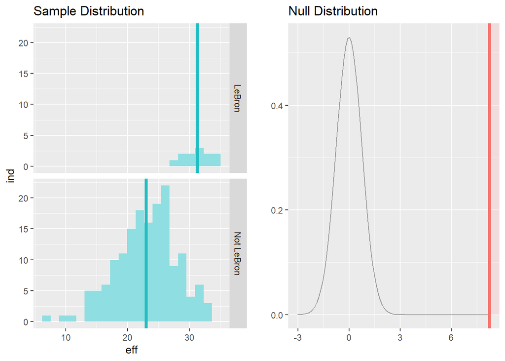

```
## $SE
## [1] 0.7520954
##
## $df
## [1] 11
##
## $t
## [1] 10.9771
##
## $p_value
## [1] 1.445265e-07
```

## THE ONE-AND-DONE RULE

In 2006, the NBA changed their eligibility rules so that all drafted players must be at least 19 years old during the year of the draft. This effectively mandated that players spend at least one year in college, hence the terminology “one-and-done”. As a Duke student, I am very familiar with this rule, as this is where our best basketball recruits come from. During my time here, I have watched the performance of many of these freshmen increase throughout the season. So, I decided to explore whether the institution of this rule generally improved the performance of rookies by evaluating their efficiency.

I implemented causal inference methods to answer this question. So, I started by creating a set of overlapping data.

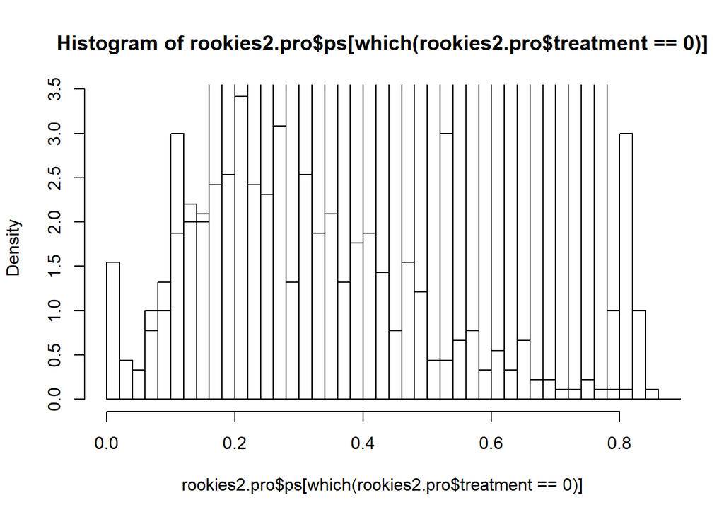

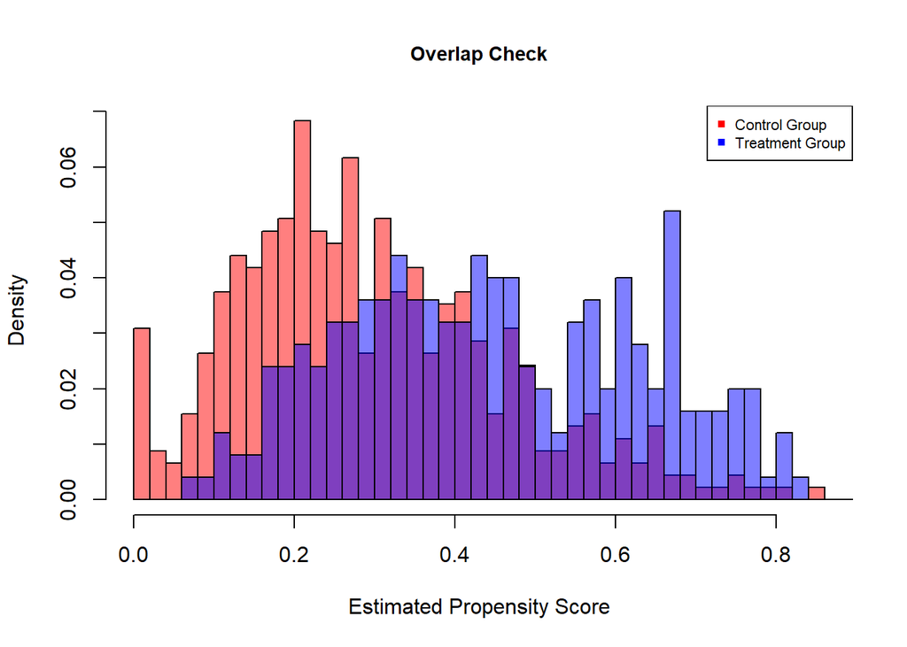

Then, I created two models using weighting and matching to determine which had the lowest average standardized difference.

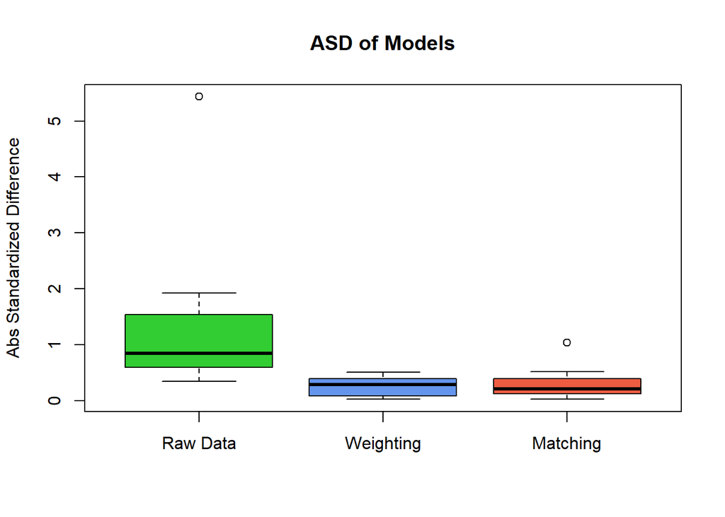

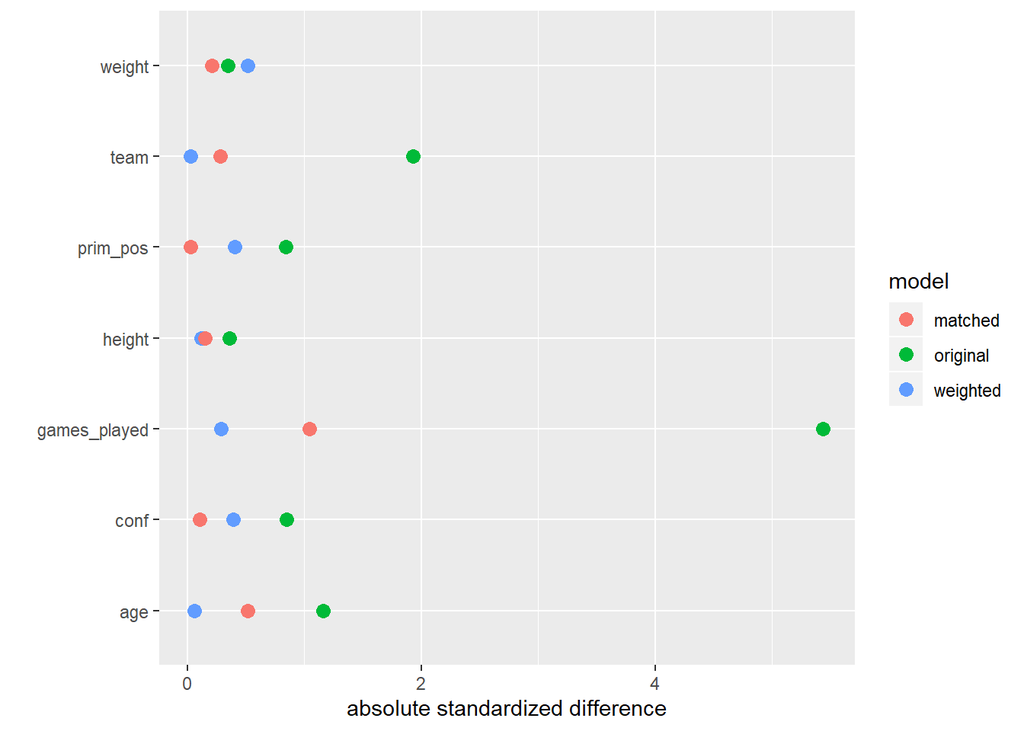

The matched model and the weighted model were pretty comparable, so I evaluated the results of the matched model so that I wouldn’t have to go the extra step of completing a regression adjustment.

```
##
## Estimate...  -1.0471
## AI SE......  0.30521
## T-stat.....  -3.4308
## p.val......  0.00060186
##
## Original number of observations..............  671
## Original number of treated obs...............  242
## Matched number of observations...............  242
## Matched number of observations  (unweighted).  1210
```

The results of the matched model show that there is a significant difference in the efficiency of rookies after the “one-and-done” rule with a p-value of 0.0006 (T-stat=-3.4308). The negative value of the T-stat indicates that the efficiency of rookies actually *decreased* after the rule took effect. I found this result incredibly surprising. I am not sure what a substantial explanation would be, but maybe this is due to the difference in the age of rookies, or forcing young athletes to go to school or participate in a foreign professional league before entering the NBA hinders their performance in some other way.